# Chicago Crime Patterns and Socioeconomic Correlates

**Group Members**: Xinying Jiang, Henry Liu

**Lecture Section**: Section 4

**GitHub**: xinying0301, henryliu1125

## Research Question

This project aims to inform the targeting of public safety and social investment resources with asking two questions: (1) What are the temporal, spatial, and categorical patterns of crime across Chicago in 2024, and (2) to what extent are neighborhood crime rates associated with socioeconomic conditions (education attainment, unemployment, and median income)?

Data sources include the City of Chicago’s crime incident dataset (filtered to 2024) and the 2024 American Community Survey 5-Year Estimates (ACS) for socioeconomic variables.

## Approach and Coding

The analysis was organized in four stages. First, : the 31 original crime types were collapsed into four categories (Violent, Property, Regulatory, Other), and ACS tables were processed to extract 11-digit GEOID codes and compute derived rates.

Second, : tracts were clipped to the Chicago city boundary, and a GeoPandas `sjoin` with predicate `within` assigned each crime point to exactly one tract. Crime rate was computed as count divided by ACS population, scaled by per 100 residents.

Third, : Produced two temporal heatmaps, two choropleth maps of crime count and rate and three socioeconomic choropleth maps.

Fourth, : Users can interactively explore crime patterns and their relationship to socioeconomic variables.

**Weaknesses and difficulties encountered:**

- : The crime dataset was filtered to 2024 only due to file size constraints, precluding time-series or trend analysis across years.
- : An initial spatial join using `intersects` without first clipping tracts to the Chicago city boundary inadvertently included partial Cook County tracts and water bodies such as Lake Michigan. This was resolved by first clipping all Illinois tracts to the Chicago city boundary shapefile, then using a `within` predicate to assign each crime point to exactly one tract.
- : The socioeconomic analysis identifies associations between tract-level conditions and crime rates but cannot establish causal relationships.

**Plots 1 & 2 — Crime Count by Month/Date and Month/Hour**

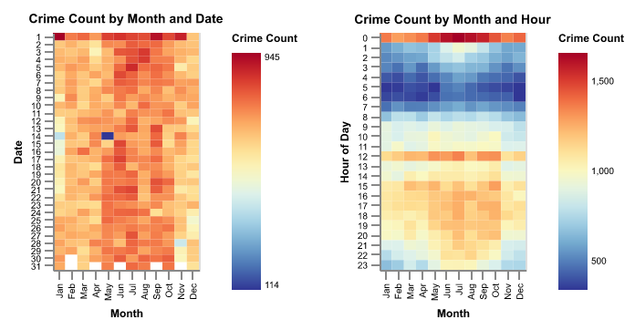

**Plots 3 & 4 — Crime Count and Crime Rate Choropleth Maps**

Plot 3 maps raw crime counts, where the Loop and Near North Side dominate due to high commercial and transit activity, making spatial variation elsewhere difficult to discern. Plot 4 adjusts for population (crime rate per 100 residents), producing a more evenly distributed and informative picture that highlights elevated risk in South and West Side tracts that would otherwise appear moderate in absolute terms.

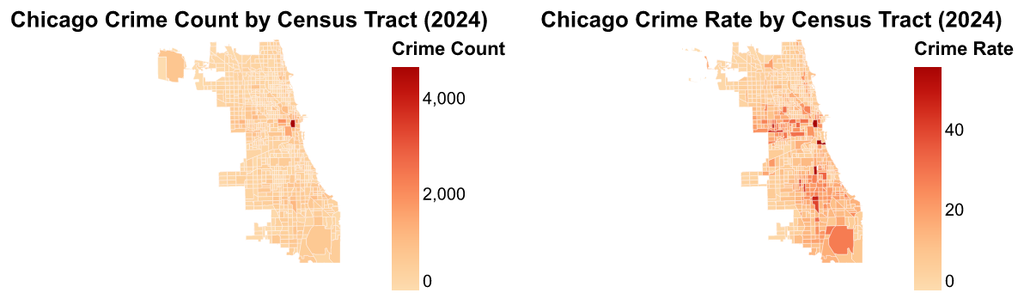

**Plots 5, 6 & 7 — Socioeconomic Choropleth Maps**

These three maps display the spatial distribution of education rate, unemployment rate, and median income across Chicago census tracts. All three exhibit geographic patterns strikingly similar to the crime rate map (Plot 4), with socioeconomic disadvantage concentrated in the same South and West Side tracts that bear the highest crime burden,which motivates the correlation analysis in the Streamlit app.

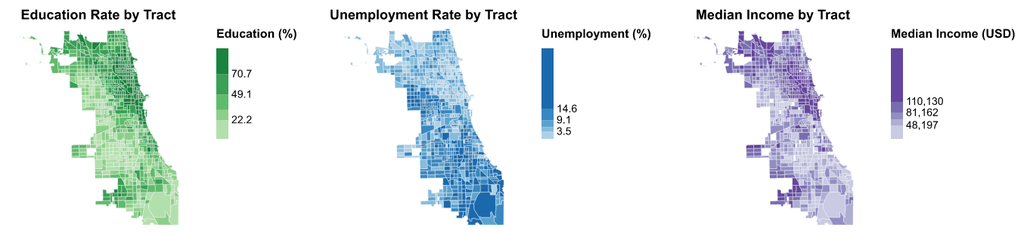

## Streamlit App

The interactive dashboard is organized into two pages with a sidebar.

**Page 1: Crime Distribution** displays a choropleth map of crime rates per 100 residents and a bar chart of crime counts by category, filterable by year, month, hour, and crime type. The South and West Side tracts bear the highest crime rates, while the Loop dominates in absolute counts due to commercial activity.

**Page 2: Socioeconomic Correlates** presents scatter plots with OLS trendlines showing crime count and crime rate against a user-selected factor: education rate, unemployment rate, or median income. Tracts with greater socioeconomic disadvantage consistently show higher crime rates, corroborating the spatial patterns in Page 1.